# R Notebook

# Multiple Regression

Comparing multiple regression to single regression can identify whether the additional parameter(s) are important

## Create the data

```r
mouse.data <- data.frame(
  weight = c(0.9, 1.8, 2.4, 3.5, 3.9, 4.4, 5.1, 5.6, 6.3),
  size = c(1.4,2.6, 1.0, 3.7, 5.5, 3.2, 3.0, 4.9, 6.3),
  tail = c(0.7, 1.3, 0.7, 2.0, 3.6, 3.0, 2.9, 3.9, 4.0)
)
mouse.data
```

| weight | size | tail |
| --- | --- | --- |
| 0.9 | 1.4 | 0.7 |
| 1.8 | 2.6 | 1.3 |
| 2.4 | 1.0 | 0.7 |
| 3.5 | 3.7 | 2.0 |
| 3.9 | 5.5 | 3.6 |
| 4.4 | 3.2 | 3.0 |
| 5.1 | 3.0 | 2.9 |
| 5.6 | 4.9 | 3.9 |
| 6.3 | 6.3 | 4.0 |

Consider a simple regression comparing weight and size

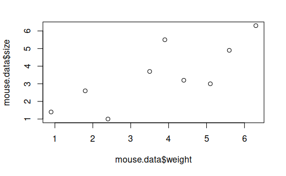

```r
plot(mouse.data$weight, mouse.data$size)
```

## Simple Regression

There is an apparent relationship, so do a simple regression

```r
simple.regression <- lm(size ~ weight, data = mouse.data)
summary(simple.regression)
```

```
Call:
lm(formula = size ~ weight, data = mouse.data)

Residuals:
    Min      1Q  Median      3Q     Max
-1.5482 -0.8037  0.1186  0.6186  1.8852

Coefficients:
            Estimate Std. Error t value Pr(>|t|)
(Intercept)   0.5813     0.9647   0.603   0.5658
weight        0.7778     0.2334   3.332   0.0126 *
---
Signif. codes:  0 ‘***’ 0.001 ‘**’ 0.01 ‘*’ 0.05 ‘.’ 0.1 ‘ ’ 1

Residual standard error: 1.19 on 7 degrees of freedom
Multiple R-squared:  0.6133,    Adjusted R-squared:  0.558
F-statistic:  11.1 on 1 and 7 DF,  p-value: 0.01256
```

The adjusted R-squred value is only useful in multple regression In this case the $R^2$ and p-value suggest weight is a useful predictor of size

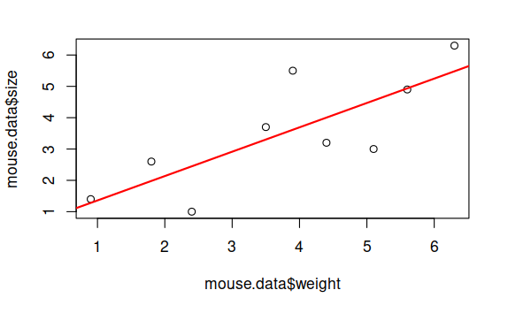

```r
plot(mouse.data$weight, mouse.data$size)
abline(simple.regression, col = "red", lwd = 2)
```

## Multiple Regression

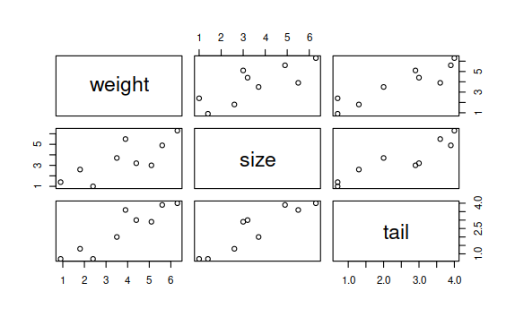

```r
plot(mouse.data)
```

By not specifying x and y axes `plot()` generates a plot for each possible pair. This suggest that weight and tail are good predictors of size. It also suggests a strong relationship between weight and tail.

Because of the strong correlation between weight and tail we might not need both since they may provide similar information

Note the difference between C1R2 and C2R1. They display the same relationship but with the axes switched

```r
multiple.regression <- lm(size ~ weight + tail, data = mouse.data)
summary(multiple.regression)
```

```
Call:
lm(formula = size ~ weight + tail, data = mouse.data)

Residuals:
     Min       1Q   Median       3Q      Max
-0.99928 -0.38648 -0.06967  0.34454  1.07932

Coefficients:
            Estimate Std. Error t value Pr(>|t|)
(Intercept)   0.7070     0.6510   1.086   0.3192
weight       -0.3293     0.3933  -0.837   0.4345
tail          1.6470     0.5363   3.071   0.0219 *
---
Signif. codes:  0 ‘***’ 0.001 ‘**’ 0.01 ‘*’ 0.05 ‘.’ 0.1 ‘ ’ 1

Residual standard error: 0.8017 on 6 degrees of freedom
Multiple R-squared:  0.8496,    Adjusted R-squared:  0.7995
F-statistic: 16.95 on 2 and 6 DF,  p-value: 0.003399
```

$R^2$ and p-values look good. Now that we are using multiple variables we should use the Adjusted R-squared value.

In this case the **Coefficients** section is more interesting weight, eg. shows a comparison between the multiple regression and a simple regression only using tail. The high p-value suggests that adding weight does not significantly improve our results. Tail compares the multiple regression to a simple regression only using weight. This result suggests that adding tail significantly improves predictions. So while the multiple regression is better, the addition of weight may not be worth the trouble and cost.